# Chapter 5: Computer Science

## Key Ideas

Complexity, Big O notation, linear complexity, logarithmic complexity, exponential complexity, list, tree, matrix, network, spaces, curves

# What’s A Computer?

In data science, we can think of a computer as an abstact device that takes data as input, completes a number of steps according to some algorithm, then returns a result. The **computational complexity** (or complexity for short) of an algorithm is an order-of-magnitude estimation of the number of steps it takes to complete. Does it take 10 steps, 100, 1,000? Because the number of algorithm steps depends on the amount of data, complexity is expressed as function of input. This expression is known as **Big O notation.**

Here are some examples of Big-O notation

[output not shown]

This chart shows the growth of algorithms based on complexity

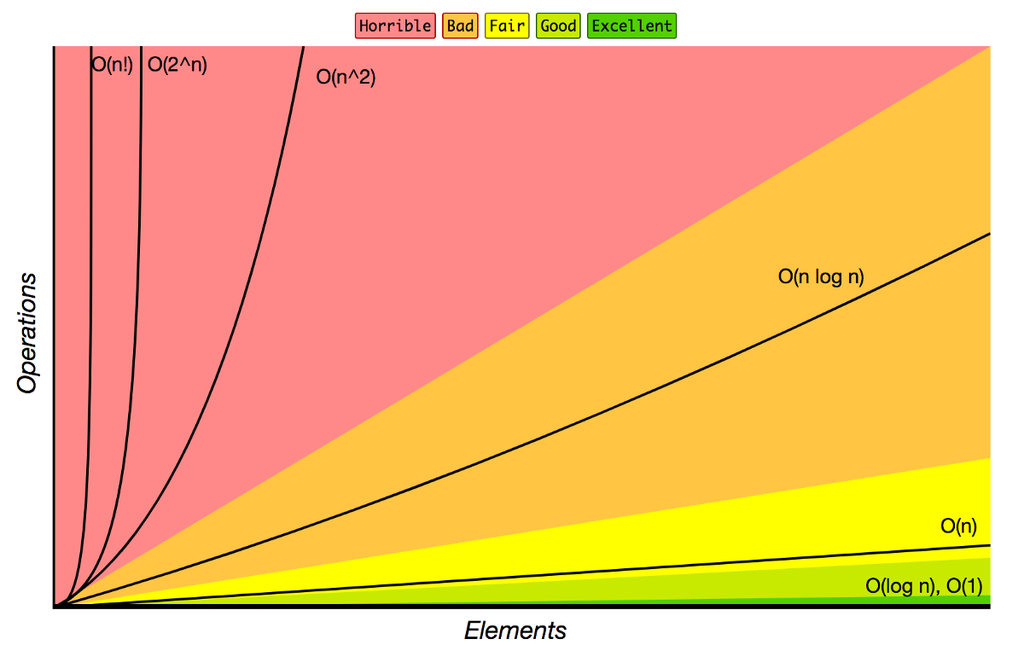

Source: Hackernoon

# Data Structures

The complexity of an algorithm is determined by the data structure of it’s model.

A **list** is a vector of items. The complexity of algorithms based on a list is usually linear.

```r
list <- c("item one", "item two", "item three", "item four")
list
```

```
[1] "item one"   "item two"   "item three" "item four"
```

A **tree** consists of nodes and connections between them. The connections leading from one node to another is called a path. Trees cannot have circular paths. The complexity of algorithms based on trees is usually linear.

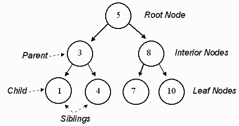

Source: StackExchange

A **matrix** is a table that shows all possible relationships between a vector of elements. The elements of the vector are listed as both the rows and columns of the matrix. Each cell of the matrix shows a particular relationship between two elements.

The following matrix shows the relationships between 4 elements. The relationship between elements 1 and 2 (row 1, column 2) is 1. The relationship between elements 3 and 4 (row 3, column 4) is 0.

The compuational complexity of algorithms based on matrices is usually exponential.

```r
row1 <- c(1,1,0,1)
row2 <- c(1,0,1,1)
row3 <- c(0,1,1,0)
row4 <- c(1,1,0,0)
matrix = matrix( c(row1,row2,row3, row4),nrow=4, ncol=4, byrow = TRUE)
matrix
```

```
     [,1] [,2] [,3] [,4]
[1,]    1    1    0    1
[2,]    1    0    1    1
[3,]    0    1    1    0
[4,]    1    1    0    0
```

A **network** is a graphical depiction of the relationships described by a matrix. You can think of a network as a tree that allows circular paths. Like matrices, the complexity of algorithms based on networks is usually exponential.

The following code takes the previous matrix and displays it as a network.

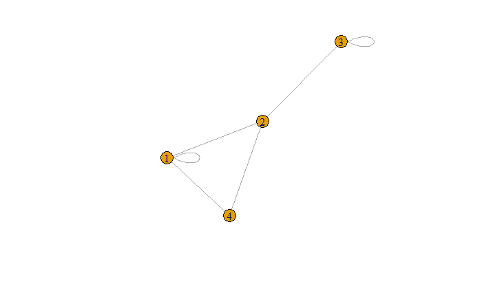

```r
if(!is_installed("igraph")){install.packages("igraph")}
library(igraph)
#turn the matrix into a graph
graph <- graph.adjacency(matrix, weighted=T, mode = "undirected")
plot(graph)
```

# Curves and Spaces

Features of a data set can be represented as the dimensions of a **space**. For example, observations of height, weight, and age can be represented as points in 3-dimensional space where each dimension corresponds to height, weight, or age.

Mathematical functions can be represented as **curves** in the space. For example, the following code shows the function *y=Sin(x)* function as a curve in space whose dimensions are *x* and *y*.

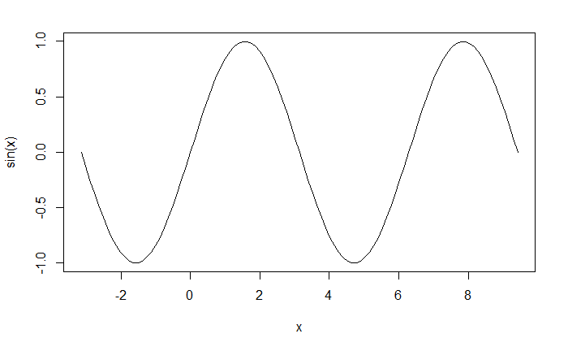

```r
curve(sin, -pi, 3*pi)
```